# Milestone3

Mengxi Tan

10/10/2019

# Raw data source

The visualization in this Milestone makes use of the data below:

Homeland Security - Immigration by Continent by Year https://www.dhs.gov/immigration-statistics/yearbook

I first downloaded table10D(legal immigration by origin by year) data for year 2005 - 2017 (custom data before 2005 was organized and ordered using different methods, and therefore was not incorporated in this project). Then I organized the by continent data into one xlsx, which I am using here for this project.

In the future, I will combine data from American Fact Finder(US Census Bureau).

# Visualizaiton

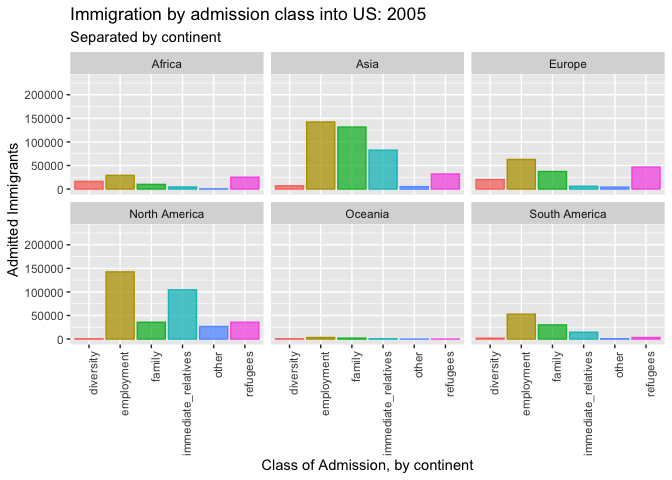

#Observations 1 :There are shifts in both total immigration count and admission class into US from the major continents. The next step will be to design a data dashboard that showcase both the overall trend and segmented patterns, and to connect immigration admission data with US Census Bureau social economic data.

#Observation 2: The gganimate graph is slow to render, and might be hard for user to digest information(even though it looks cool!) Therefore, I will see what’s the capability for Shiny package, and may use a slider instead.